# HW3_3

2022-11-11

```r
knitr::opts_chunk$set(echo = TRUE)
library(NHANES)
library(dplyr)
library(stringr)
library(tidyr)
library(tidyverse)
library(olsrr)
library(MASS)
library(boot)
library(haven)
```

# Question 1

## Question 1a

### Data Wrangling

Here I changed HHIncome variable from (min-max) format to into two colummns

```r
NHANES_1= NHANES %>% dplyr::select(Gender,Age, Race1, Education,HHIncome,HomeOwn,Weight,Height,BMI,PhysActive)
NHANES_1$HHIncome= as.character(NHANES_1$HHIncome)
temp= NHANES_1$HHIncome%>% str_split_fixed("-",2) %>%  data.frame()
NHANES_1= NHANES_1 %>%  mutate(min_Income= (temp$X1), max_Income= (temp$X2)) %>%
  mutate(min_Income= ifelse(min_Income=="more 99999", "99999",min_Income)) %>%
  mutate(max_Income= ifelse(max_Income=="", 100000, max_Income))
NHANES_1$min_Income= as.integer(NHANES_1$min_Income)
NHANES_1$max_Income= as.integer(NHANES_1$max_Income)
```

Encoding into Binary Values

```r
NHANES_1=NHANES_1 %>% mutate(
          male=ifelse(Gender== "male", 1,0),
          white= ifelse(Race1 =="White",1,0),
          black= ifelse(Race1== "Black",1,0),
          hs=ifelse(Education%in% c("High School", "Some College", "College Grad"),1,0),
          income_high=ifelse(max_Income>= 75000, 1,0),
          income_low= ifelse(max_Income <=25000, 1,0),
          own= ifelse(HomeOwn== "Own",1,0),
          phy_act_yes= ifelse(PhysActive== "Yes",1,0)
         )

NHANES_1=NHANES_1 %>%  dplyr::select(BMI,Age,male,white,black,hs,income_high,income_low,own,phy_act_yes)
```

## Question 1b

```r
NHANES_1=NHANES_1[complete.cases(NHANES_1),]
paste("The rows of our dataset is: ", nrow(NHANES_1))
```

```
## [1] "The rows of our dataset is:  8194"
```

## Question 1c

```r
model_1c= lm(BMI~phy_act_yes,data=NHANES_1)
summary(model_1c)
```

```
##
## Call:
## lm(formula = BMI ~ phy_act_yes, data = NHANES_1)
##
## Residuals:
##     Min      1Q  Median      3Q     Max
## -14.892  -4.612  -1.042   3.578  51.808
##
## Coefficients:
##             Estimate Std. Error t value Pr(>|t|)
## (Intercept)  29.4423     0.1114  264.36   <2e-16 ***
## phy_act_yes  -2.3307     0.1489  -15.65   <2e-16 ***
## ---
## Signif. codes:  0 '***' 0.001 '**' 0.01 '*' 0.05 '.' 0.1 ' ' 1
##
## Residual standard error: 6.691 on 8192 degrees of freedom
## Multiple R-squared:  0.02904,    Adjusted R-squared:  0.02893
## F-statistic:   245 on 1 and 8192 DF,  p-value: < 2.2e-16
```

The B1 coefficient is -2.3307(2sf), which shows that for those who are physically active have lower BMIs than those who do not The B1 coefficient is statistically significant as we can see from the very small p value. The R squared value is 0.02904 so around 3% of the variation in BMI can be explained by whether someone does physical activity.

## Question 1d

```r
model_1d = lm(BMI~.,data=NHANES_1)
summary(model_1d)
```

```
##
## Call:
## lm(formula = BMI ~ ., data = NHANES_1)
##
## Residuals:
##     Min      1Q  Median      3Q     Max
## -16.261  -4.460  -1.068   3.338  51.213
##
## Coefficients:
##              Estimate Std. Error t value Pr(>|t|)
## (Intercept) 26.393200   0.275709  95.728  < 2e-16 ***
## Age          0.041816   0.004293   9.740  < 2e-16 ***
## male         0.224187   0.144948   1.547   0.1220
## white       -0.067882   0.184578  -0.368   0.7131
## black        1.936569   0.260888   7.423 1.26e-13 ***
## hs           1.797914   0.171882  10.460  < 2e-16 ***
## income_high -1.017167   0.165395  -6.150 8.12e-10 ***
## income_low   0.218109   0.204171   1.068   0.2854
## own         -0.334702   0.169919  -1.970   0.0489 *
## phy_act_yes -1.824190   0.153410 -11.891  < 2e-16 ***
## ---
## Signif. codes:  0 '***' 0.001 '**' 0.01 '*' 0.05 '.' 0.1 ' ' 1
##
## Residual standard error: 6.53 on 8184 degrees of freedom
## Multiple R-squared:  0.07613,    Adjusted R-squared:  0.07512
## F-statistic: 74.94 on 9 and 8184 DF,  p-value: < 2.2e-16
```

The Beta_phys_act_yes coefficient is -1.824190, which shows that for those who are physically active have lower BMIs than those who do not The B1 coefficient is statistically significant as we can see from the very small p value

If we compare model_1c’s R-squared value and model_1d’s adjusted R-squared value, model_1d’s higher adjusted R-square’s value suggests that model_1d predictor variables explain more of the variation in BMI.

## Question 1e

```r
stepAIC(model_1d)
```

```
## Start:  AIC=30759.86
## BMI ~ Age + male + white + black + hs + income_high + income_low +
##     own + phy_act_yes
##
##               Df Sum of Sq    RSS   AIC
## - white        1       5.8 348949 30758
## - income_low   1      48.7 348992 30759
## <none>                     348944 30760
## - male         1     102.0 349046 30760
## - own          1     165.4 349109 30762
## - income_high  1    1612.6 350556 30796
## - black        1    2349.4 351293 30813
## - Age          1    4045.1 352989 30852
## - hs           1    4665.1 353609 30867
## - phy_act_yes  1    6028.7 354972 30898
##
## Step:  AIC=30757.99
## BMI ~ Age + male + black + hs + income_high + income_low + own +
##     phy_act_yes
##
##               Df Sum of Sq    RSS   AIC
## - income_low   1      49.6 348999 30757
## <none>                     348949 30758
## - male         1     102.3 349052 30758
## - own          1     177.8 349127 30760
## - income_high  1    1616.4 350566 30794
## - black        1    3241.9 352191 30832
## - Age          1    4057.7 353007 30851
## - hs           1    4724.6 353674 30866
## - phy_act_yes  1    6075.8 355025 30897
##
## Step:  AIC=30757.16
## BMI ~ Age + male + black + hs + income_high + own + phy_act_yes
##
##               Df Sum of Sq    RSS   AIC
## <none>                     348999 30757
## - male         1      96.6 349096 30757
## - own          1     221.3 349220 30760
## - income_high  1    2102.4 351101 30804
## - black        1    3302.3 352301 30832
## - Age          1    4127.1 353126 30852
## - hs           1    4680.3 353679 30864
## - phy_act_yes  1    6094.9 355094 30897
```

```
##
## Call:
## lm(formula = BMI ~ Age + male + black + hs + income_high + own +
##     phy_act_yes, data = NHANES_1)
##
## Coefficients:
## (Intercept)          Age         male        black           hs  income_high
##    26.46711      0.04193      0.21802      1.99830      1.76344     -1.08270
##         own  phy_act_yes
##    -0.37675     -1.83036
```

Age , male , black , hs , income_high , own , phy_act_yes are the variables chosen by the AIC backward selection model to explain the variation in BMI.

# Exercise 2

## Exercise 2a)

```r
model_2a= glm(phy_act_yes~BMI,data= NHANES_1,family= "binomial")
summary(model_2a)
```

```
##
## Call:
## glm(formula = phy_act_yes ~ BMI, family = "binomial", data = NHANES_1)
##
## Deviance Residuals:
##     Min       1Q   Median       3Q      Max
## -1.5996  -1.2488   0.9136   1.0499   1.8870
##
## Coefficients:
##              Estimate Std. Error z value Pr(>|z|)
## (Intercept)  1.714081   0.100504   17.05   <2e-16 ***
## BMI         -0.052290   0.003472  -15.06   <2e-16 ***
## ---
## Signif. codes:  0 '***' 0.001 '**' 0.01 '*' 0.05 '.' 0.1 ' ' 1
##
## (Dispersion parameter for binomial family taken to be 1)
##
##     Null deviance: 11243  on 8193  degrees of freedom
## Residual deviance: 11002  on 8192  degrees of freedom
## AIC: 11006
##
## Number of Fisher Scoring iterations: 4
```

Here, we can see that the logarithm of physical activity decreases by 0.05229009 for every increase of BMI by 1

### Odd Ratios

```r
exp(coef(model_2a)[2])
```

```
##       BMI
## 0.9490535
```

As BMI increases by 1 unit, the predicted odds are multiplied by 0.9490535, meaning that the chance of physical activity decreases by a factor of 0.9490535 for every increase in 1 unit of BMI. The p-value for the Beta1 coefficient is small, so it is statistically significant. We can visualise this relationship down below.

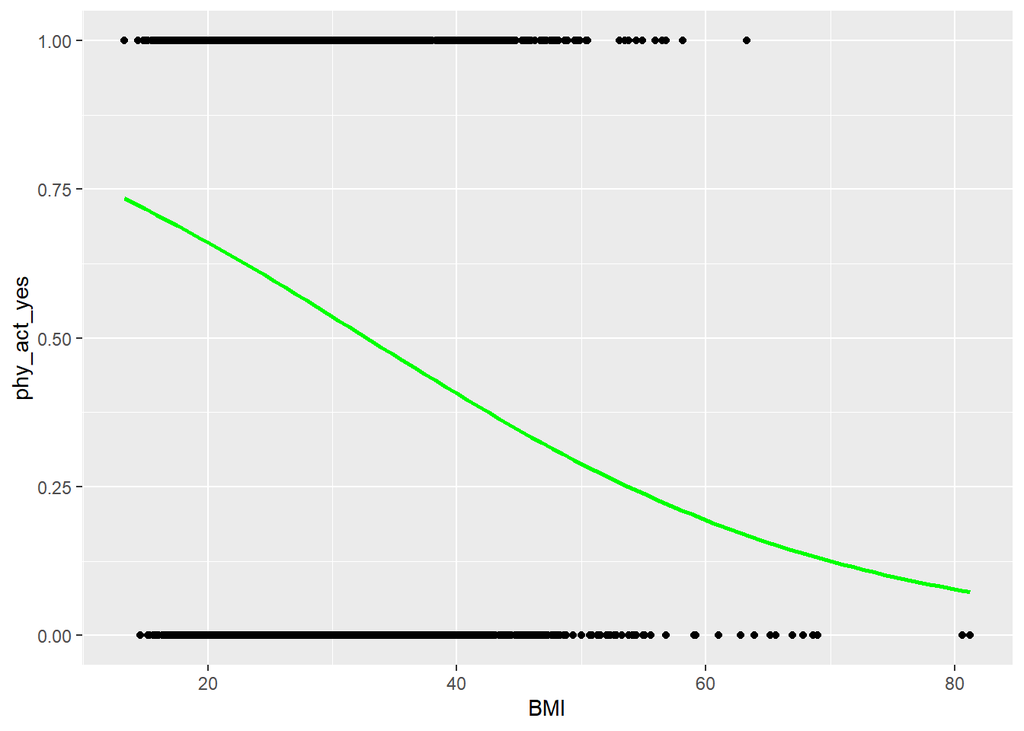

```r
ggplot(NHANES_1,aes(BMI,phy_act_yes))+geom_point()+
  stat_smooth(method="glm",color="green",se=FALSE,
              method.args=list(family=binomial))
```

## Exericse 2b

```r
model_2.1= glm(phy_act_yes~BMI, data= NHANES_1,family= "binomial")
model_2.2= glm(phy_act_yes~BMI+male+Age, data= NHANES_1,family= "binomial")
model_2.3= glm(phy_act_yes ~ BMI + male + Age+white+ black, data= NHANES_1,family= "binomial")
model_2.4= glm(phy_act_yes ~ BMI + male + Age + white + black + income_high + income_low, data= NHANES_1,family= "binomial")
model_2.5= glm(phy_act_yes ~ BMI + male + Age + white + black + income_high + income_low + hs + own, data= NHANES_1,family= "binomial")
```

The p-value for each model BMI coefficient in respective order

```r
for(i in 1:4){
  print(paste("The p-value of model ", i, " is: ", summary(get(paste0("model_2.",i)))$coef[2,4]))
}
```

```
## [1] "The p-value of model  1  is:  3.03176667820306e-51"
## [1] "The p-value of model  2  is:  4.86597169232384e-34"
## [1] "The p-value of model  3  is:  1.28316305039238e-31"
## [1] "The p-value of model  4  is:  4.03184510087793e-27"
```

As we can see, for all models, the BMI Beta coefficient had a very small value so the BMI value is a statistically significant explanatory variable for predicting physical acitivity

```r
coef_2b=data.frame(model_2.1=c(coef(model_2.1),rep(NA, 10-length(coef(model_2.1)))),
           model_2.2=c(coef(model_2.2),rep(NA, 10-length(coef(model_2.2)))),
           model_2.3=c(coef(model_2.3),rep(NA, 10-length(coef(model_2.3)))),
           model_2.4=c(coef(model_2.4),rep(NA, 10-length(coef(model_2.4)))),
           model_2.5=c(coef(model_2.5),rep(NA, 10-length(coef(model_2.5))))
) %>% print()
```

```
##               model_2.1   model_2.2   model_2.3   model_2.4   model_2.5
## (Intercept)  1.71408132  2.39693304  2.11194069  1.95510774  1.72063127
## BMI         -0.05229009 -0.04310225 -0.04190136 -0.03895442 -0.04234013
## male                 NA  0.19744266  0.20180085  0.18553007  0.22086775
## Age                  NA -0.02377913 -0.02663335 -0.02668941 -0.03219776
## white                NA          NA  0.55291086  0.48247350  0.33368409
## black                NA          NA  0.11458371  0.14279155  0.08957956
## income_high          NA          NA          NA  0.42567958  0.34200994
## income_low           NA          NA          NA -0.23163624 -0.07667734
## hs                   NA          NA          NA          NA  0.60552550
## own                  NA          NA          NA          NA  0.33494429
```

```r
odd_2b=coef_2b[2,] %>% pluck() %>% exp() %>% print()
```

```
##     model_2.1 model_2.2 model_2.3 model_2.4 model_2.5
## BMI 0.9490535 0.9578135 0.9589644 0.9617945 0.9585437
```

```r
for(i in 1: 4){
    print(paste("Difference between coefficient of model ", i+1, " and ", i, " is ",odd_2b[i+1]-odd_2b[i]))
}
```

```
## [1] "Difference between coefficient of model  2  and  1  is  0.00875993790577423"
## [1] "Difference between coefficient of model  3  and  2  is  0.0011509183916093"
## [1] "Difference between coefficient of model  4  and  3  is  0.0028301749962758"
## [1] "Difference between coefficient of model  5  and  4  is  -0.00325084472342452"
```

The change in Beta coefficient is a function of the magnitude of (1) the correlation between BMI variable and added variable and (2) the correlation between the added variable and phy_act_yes. As we can see the max change in Beta coefficient occurs between model 2 and model 1 when the Age variable is added. The Age variable is the most correlated with BMI and phy_act_yes.

```r
cor(NHANES_1) %>% data.frame() %>% dplyr::select(BMI) %>% arrange(abs(BMI) %>% desc())
```

```
##                      BMI
## BMI          1.000000000
## Age          0.172525267
## phy_act_yes -0.170422826
## hs           0.126018373
## black        0.101216222
## income_high -0.100607029
## income_low   0.052454654
## white       -0.031819021
## own         -0.022781206
## male        -0.005373119
```

```r
cor(NHANES_1) %>% data.frame() %>% dplyr::select(phy_act_yes) %>% arrange(abs(phy_act_yes) %>% desc())
```

```
##             phy_act_yes
## phy_act_yes  1.00000000
## Age         -0.23732099
## BMI         -0.17042283
## income_high  0.14209445
## income_low  -0.10134727
## white        0.07236480
## hs           0.06193732
## male         0.05573801
## own          0.05177111
## black       -0.04599531
```

This is called the *omited variable bias* and occurs when the model 1 misses out relevant variables. If Y is caused by both Xi and Xj, where Xi and Xj are correlated, but Xj is omitted, some or the variation in Y due to Xj will be innapropriately attributed to Xi, making Xi biased.

## Question 2c

```r
set.seed(1)
cv.error.5 <- rep(0, 5)
for(i in 1:5){
  cv.error.5[i]= cv.glm(NHANES_1, get(paste0("model_2.",i)),K=10)$delta[1]
}
cv.error.5
```

```
## [1] 0.2393451 0.2282011 0.2251833 0.2217704 0.2177472
```

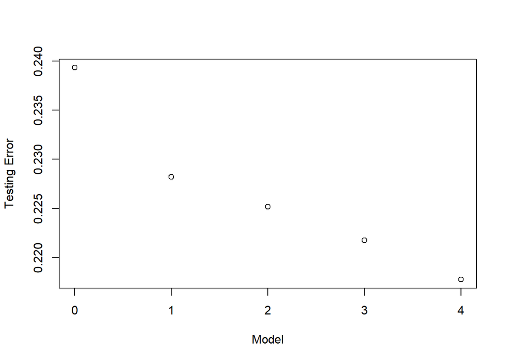

```r
plot(0:4, cv.error.5,xlab= "Model", ylab="Testing Error")
```

Here, we can see that there is the first drop from model_2.1 to model_2.2 then a drop from model_2.4 to model_2.5 This suggests that adding male, age, white, black, income_high, income_low, hs, own will lead to lower test error terms than the model with only BMI.

# Question 3

## Question 3a

```r
hn19= read_sas("HN19_ALL.sas7bdat")
```

어떠한 요인이 우울증을 유발할까요?

크게 3가지로 결혼생활의 불화, 신체적 결함, 안 좋은 습관을 떠올릴 수 있습니다. 가화만사성은 정말 사실일까?에 대한 궁금증에서 시작하여 저희는

우을감에 결혼생활이 얼마나 영향을미치는 가를 분석하고자 합니다.

우을을 판단하는 변수는 아래와 같습니다. BP_5: 2주 이상 연속 우울감 여부 1:예 2:아니오 (Discrete categorical nominal data)

1.결혼생활을 판별하는 변수는 아래와 같습니다. marri_2 결혼상태 1: 유배우자,동거 2~4: 별거, 사별, 이혼

안 좋은 습관에 대한 변수는 아래와 같습니다. LQ_7HT: 잠자기 1: 잠을 자는데 어려움이 없다. 2~4: 잠을 자는데 어려움이 약간/많이/절대적으로 있다. BS1_1: 평생 흡연여부 1: 5값 미만 2: 5갑 이상 BD2_31: 폭음빈도 1: 전혀없음 2: 월1회미만 3: 월1회정도 4: 주 1회정도 5: 거의매일

신체적 결함에 대한 변수는 아래와 같습니다. 질환에 대한 노출 여부와 체형을 판단하기 위한 지표입니다. D_1_1: 주관적 건강인지 1~3: 매우좋음,좋음 보통 4~5: 나쁨, 매우나쁨 BO1: 주관적 체형인식 1: 매우 마른편, 2: 약간 마른편, 3: 보통, 4: 약간 비만, 5:매우비만

We can see the relationship in the paper below: (https://pubmed.ncbi.nlm.nih.gov/29861378/) To quote the results, “Participants with short sleep duration (<5 and 5-6 h) had a higher risk of depression onset (OR 1.69 [1.36-2.11], 1.48 [1.19-1.84]) and recurrent depression (OR 1.44 [1.12-1.86], 1.32 [1.00-1.74]) compared to participants with normal sleep durations (7-8 h).”

### Data Wrangling

```r
hn19=hn19%>%
  dplyr::select(marri_2,D_1_1,BP5,LQ_7HT,BS1_1,BD2_31)%>%
  filter(marri_2 %in% c(1,2,3,4))%>%
  filter(D_1_1!=9)%>%
  filter(LQ_7HT %in% c(1,2,3,4))%>%
  filter(BD2_31 %in% c(1,2,3,4,5))%>%
  filter(BS1_1 %in% c(1,2,3))%>%
  filter(BP5 %in% c(1,2))
hn19$marri_2= as.factor(hn19$marri_2)
```

```r
hn19=hn19%>% mutate(D_1_1_cat=ifelse(D_1_1 %in% c(4,5),1,0),
                    BP5_cat=ifelse(BP5==1,1,0),
                    LQ_7HT_cat=ifelse(LQ_7HT>2,1,0),
                    BD2_31_cat=ifelse(BD2_31==1,0,1),
                    BS1_1_cat=ifelse(BS1_1==3,0,1),
)
```

```r
model_3=glm(BP5_cat~marri_2+D_1_1_cat+LQ_7HT_cat+BD2_31_cat+BS1_1_cat,  data=hn19, family="binomial")
```

We use a logistic regression model since the outcome is binomial and we can use the predictor variables to see whether an individual will have depression or not

## Question 3b

```r
summary(model_3)
```

```
##
## Call:
## glm(formula = BP5_cat ~ marri_2 + D_1_1_cat + LQ_7HT_cat + BD2_31_cat +
##     BS1_1_cat, family = "binomial", data = hn19)
##
## Deviance Residuals:
##     Min       1Q   Median       3Q      Max
## -1.2633  -0.3721  -0.3654  -0.3605   2.3672
##
## Coefficients:
##             Estimate Std. Error z value Pr(>|z|)
## (Intercept) -2.67340    0.11207 -23.854  < 2e-16 ***
## marri_22     0.62063    0.66226   0.937 0.348683
## marri_23     1.03415    0.19209   5.384 7.30e-08 ***
## marri_24     0.73639    0.20846   3.532 0.000412 ***
## D_1_1_cat    0.58960    0.14926   3.950 7.81e-05 ***
## LQ_7HT_cat   1.21136    0.15821   7.657 1.91e-14 ***
## BD2_31_cat   0.03799    0.13604   0.279 0.780069
## BS1_1_cat   -0.06573    0.13495  -0.487 0.626195
## ---
## Signif. codes:  0 '***' 0.001 '**' 0.01 '*' 0.05 '.' 0.1 ' ' 1
##
## (Dispersion parameter for binomial family taken to be 1)
##
##     Null deviance: 2108.1  on 3355  degrees of freedom
## Residual deviance: 1976.6  on 3348  degrees of freedom
## AIC: 1992.6
##
## Number of Fisher Scoring iterations: 5
```

We can see that marri_22, BD2_31_cat, BS1_1_cat are all not significantly significant variables in explaining the variation in BP5_cat.

We can confirm this using the backward AIC selection

```r
stepAIC(model_3)
```

```
## Start:  AIC=1992.59
## BP5_cat ~ marri_2 + D_1_1_cat + LQ_7HT_cat + BD2_31_cat + BS1_1_cat
##
##              Df Deviance    AIC
## - BD2_31_cat  1   1976.7 1990.7
## - BS1_1_cat   1   1976.8 1990.8
## <none>            1976.6 1992.6
## - D_1_1_cat   1   1991.2 2005.2
## - marri_2     3   2010.7 2020.7
## - LQ_7HT_cat  1   2028.3 2042.3
##
## Step:  AIC=1990.67
## BP5_cat ~ marri_2 + D_1_1_cat + LQ_7HT_cat + BS1_1_cat
##
##              Df Deviance    AIC
## - BS1_1_cat   1   1976.8 1988.8
## <none>            1976.7 1990.7
## - D_1_1_cat   1   1991.2 2003.2
## - marri_2     3   2010.8 2018.8
## - LQ_7HT_cat  1   2028.7 2040.7
##
## Step:  AIC=1988.83
## BP5_cat ~ marri_2 + D_1_1_cat + LQ_7HT_cat
##
##              Df Deviance    AIC
## <none>            1976.8 1988.8
## - D_1_1_cat   1   1991.3 2001.3
## - marri_2     3   2011.8 2017.8
## - LQ_7HT_cat  1   2028.8 2038.8
```

```
##
## Call:  glm(formula = BP5_cat ~ marri_2 + D_1_1_cat + LQ_7HT_cat, family = "binomial",
##     data = hn19)
##
## Coefficients:
## (Intercept)     marri_22     marri_23     marri_24    D_1_1_cat   LQ_7HT_cat
##     -2.6820       0.6306       1.0397       0.7346       0.5877       1.2135
##
## Degrees of Freedom: 3355 Total (i.e. Null);  3350 Residual
## Null Deviance:       2108
## Residual Deviance: 1977  AIC: 1989
```

So we choose BP5_cat ~ marri_2 + D_1_1_cat + LQ_7HT_cat for our final model.

## Question 3c

```r
model_3c0=glm(BP5_cat~marri_2,  data=hn19, family="binomial")
model_3c1=glm(BP5_cat~marri_2+D_1_1_cat+LQ_7HT_cat,  data=hn19, family="binomial")
model_3c2=glm(BP5_cat~marri_2+D_1_1_cat+LQ_7HT_cat+marri_2*D_1_1_cat, data=hn19, family="binomial")
model_3c3=glm(BP5_cat~marri_2+D_1_1_cat+LQ_7HT_cat+marri_2*LQ_7HT_cat,  data=hn19, family="binomial")
model_3c4=glm(BP5_cat~marri_2+D_1_1_cat+LQ_7HT_cat+marri_2*D_1_1_cat+marri_2*LQ_7HT_cat,  data=hn19, family="binomial")
model_3c5=glm(BP5_cat~marri_2+D_1_1_cat+LQ_7HT_cat+marri_2*D_1_1_cat+D_1_1_cat*LQ_7HT_cat,  data=hn19, family="binomial")
model_3c6=glm(BP5_cat~marri_2+D_1_1_cat+LQ_7HT_cat+marri_2*LQ_7HT_cat+D_1_1_cat*LQ_7HT_cat,  data=hn19, family="binomial")
model_3c7=glm(BP5_cat~marri_2+D_1_1_cat+LQ_7HT_cat+marri_2*D_1_1_cat+marri_2*LQ_7HT_cat+D_1_1_cat*LQ_7HT_cat,  data=hn19, family="binomial")


set.seed(17)
cv.error.8 <- rep(0, 8)
for (i in 0:7) {
  cv.error.8[i+1] <- cv.glm(hn19, get(paste0("model_3c",i)), K = 10)$delta[1]
}
```

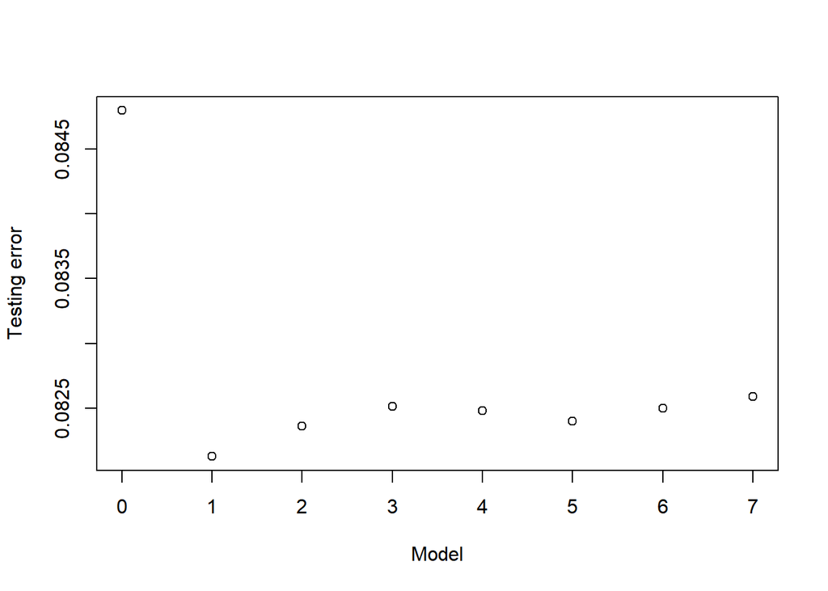

```r
plot(1:8-1,cv.error.8,xlab= "Model", ylab="Testing error")
```

We can see that testing error is the lowest for model 1 so we choose as our model- which has no interactions. This model is BP5_cat~marri_2+D_1_1_cat+LQ_7HT_cat.

```r
model_coef3= list()
for (i in 0:7){
  model_coef3[[i+1]]=coef(get(paste0("model_3c",i)))[2:4]
}
model_coef3
```

```
## [[1]]
##  marri_22  marri_23  marri_24
## 0.7608206 1.1662857 0.9113016
##
## [[2]]
##  marri_22  marri_23  marri_24
## 0.6305796 1.0396946 0.7346389
##
## [[3]]
##  marri_22  marri_23  marri_24
## 0.5577606 1.1779787 0.5237019
##
## [[4]]
##  marri_22  marri_23  marri_24
## 0.7329081 1.1175674 0.5351194
##
## [[5]]
##  marri_22  marri_23  marri_24
## 0.7294851 1.2080293 0.3662270
##
## [[6]]
##  marri_22  marri_23  marri_24
## 0.5578650 1.1780167 0.5228322
##
## [[7]]
##  marri_22  marri_23  marri_24
## 0.7305692 1.1184709 0.5356791
##
## [[8]]
##  marri_22  marri_23  marri_24
## 0.7301457 1.2078903 0.3653698
```

## Odds ratio of model with single predictor and new model

```r
model_coef3[[1]] %>% exp()
```

```
## marri_22 marri_23 marri_24
## 2.140032 3.210047 2.487558
```

```r
model_coef3[[2]] %>% exp()
```

```
## marri_22 marri_23 marri_24
## 1.878699 2.828353 2.084729
```